# Project: TMDb Movie Data Analysis

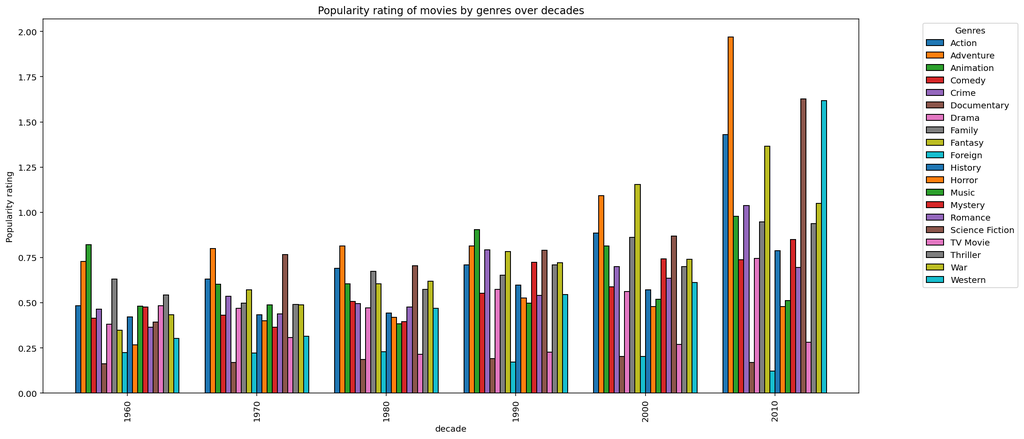

```python
df_genres = df_decade.pivot("release_decade", "genres", "popularity")
X = np.arange(4)
df_genres.plot(kind='bar',width=0.8,figsize=(17,8), edgecolor = "black")
plt.legend(bbox_to_anchor=(1.2,1), loc='upper right', ncol=1,title="Genres")
plt.title("Popularity rating of movies by genres over decades")
plt.xlabel("decade")
plt.ylabel("Popularity rating")
plt.show()
```

### Research Question 2: What properties are associated with highly profitable movies?

```python
df_film_max = df.loc[df.groupby('release_year')['revenue'].idxmax()]
```

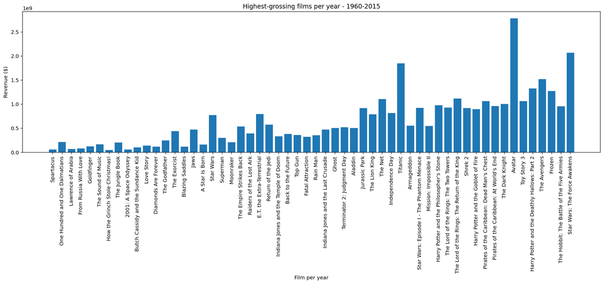

```python
plt.figure(figsize=(20,5))
plt.bar(df_film_max.original_title, df_film_max.revenue)
plt.xticks(df_film_max.original_title, rotation = 90)
plt.xlabel('Film per year')
plt.ylabel('Revenue ($)')
plt.title('Highest-grossing films per year - 1960-2015')
plt.show()
```

Above plot shows the HIghest grossing films over the years. Avatar stood first in collecting revenue, second is Starwars and third is Titanic.

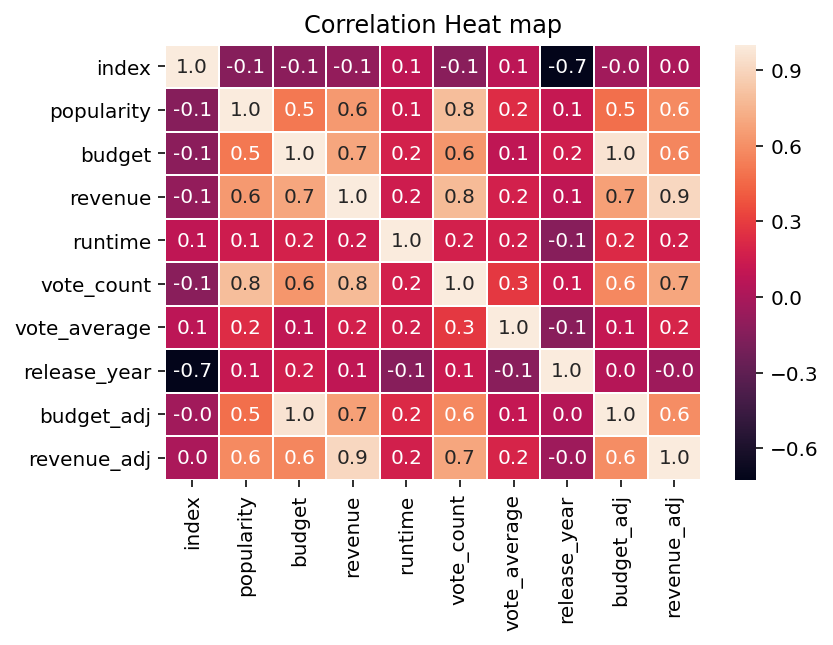

```python
sns.heatmap(df.corr(), annot=True, linewidths=.5, fmt='.1f');
plt.title("Correlation Heat map");
```

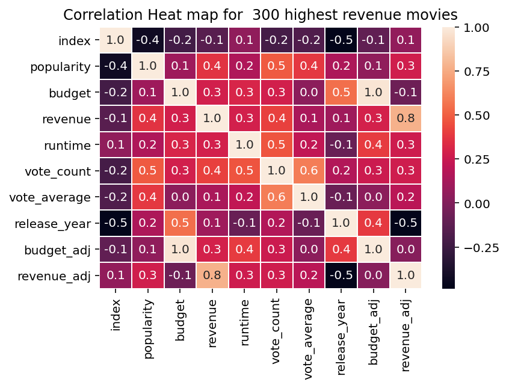

```python
sns.heatmap(df.sort_values(by = 'revenue', ascending = False).head(300).corr(),annot=True, linewidths=.5, fmt='.1f');
plt.title("Correlation Heat map for  300 highest revenue movies");
```

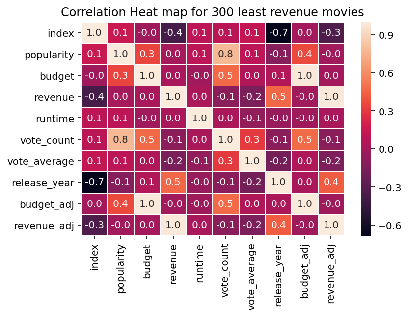

```python
sns.heatmap(df.sort_values(by = 'revenue', ascending = True).head(300).corr(),annot=True, linewidths=.5, fmt='.1f');
plt.title("Correlation Heat map for 300 least revenue movies");
```

The Above three Plots Shows the corealtion between the columns. 1st plot shows overall correlation 2nd plot shows the correaction for 300 heighest revenue movies. 3rd plot shows the correaction for 300 lowest revenue movies.

```python
def scat(data):
    x = df["revenue"]
    y = df[data]
    plt.scatter(x, y)
    plt.title("revenue vs "+data)
    plt.xlabel("revenue")
    plt.ylabel(data)
    plt.show()
```

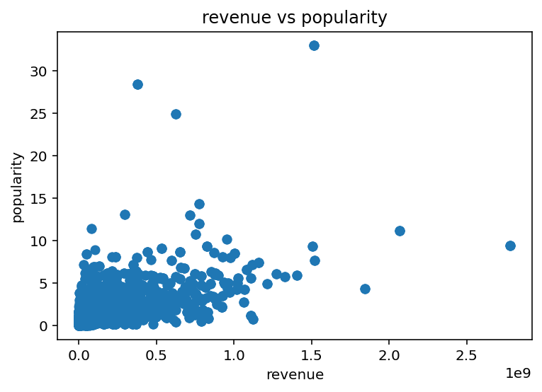

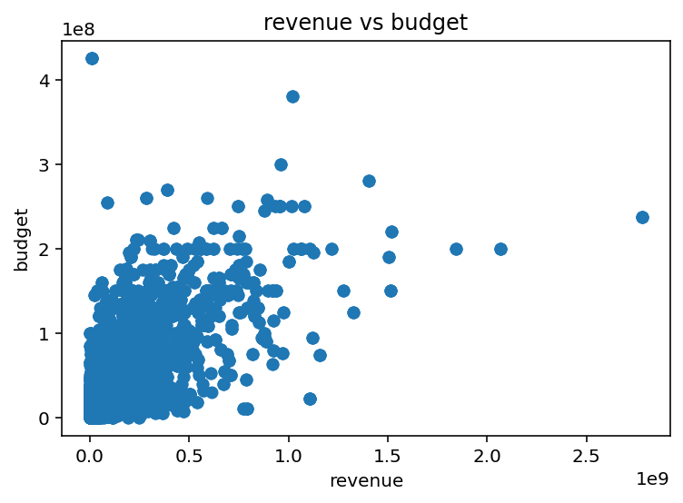

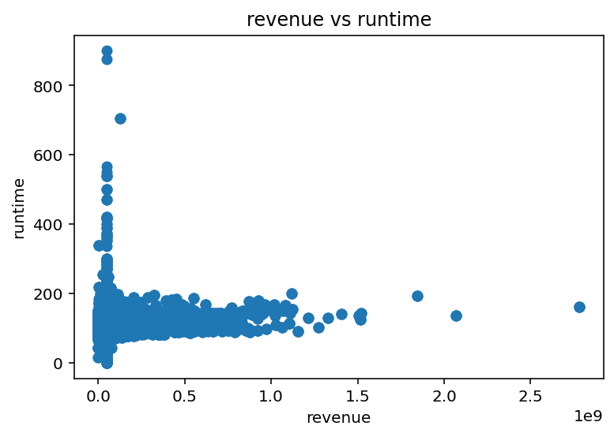

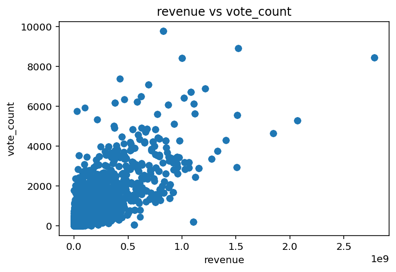

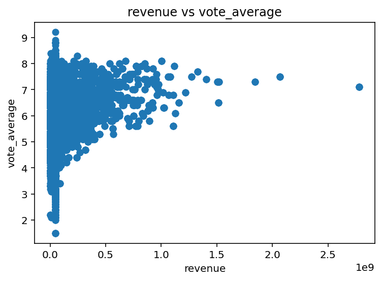

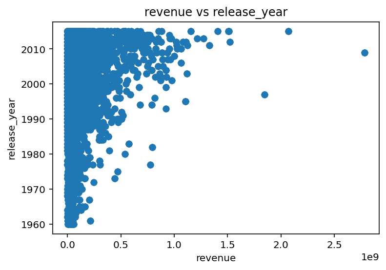

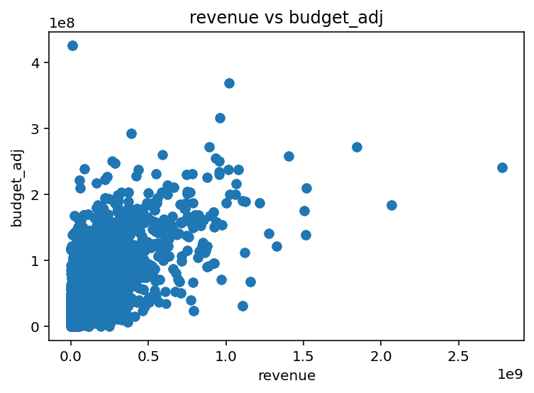

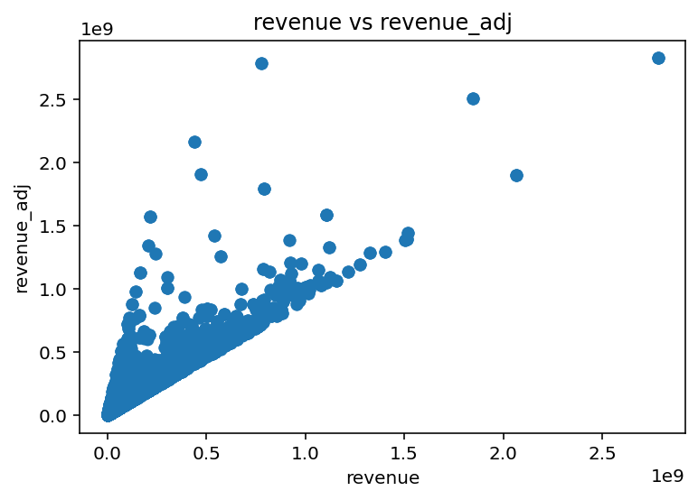

```python
numerics = ['int64','float64']
columns = df.drop(columns=["index","revenue"]).select_dtypes(include=numerics).columns
j = 1
for i in columns:
    scat(i)
```

The above scatter plots shows the correlation between revenue and other columns. columns Popularity, budget, runtime, vote_count, vote average,release_year have positive correlation with revenue.

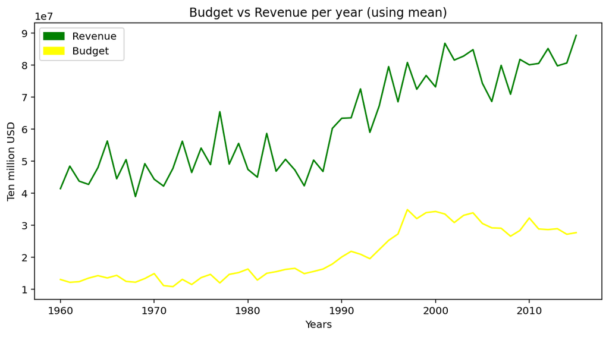

```python
df_budgetrev = df.groupby(['release_year'])['budget','revenue'].mean()
plt.figure(figsize=(10,5))

p1,=plt.plot(df_budgetrev.index, df_budgetrev.budget, color='yellow')
p2, = plt.plot(df_budgetrev.index, df_budgetrev.revenue, color='green')
plt.xlabel('Years')
plt.ylabel('Ten million USD')
plt.title('Budget vs Revenue per year (using mean)')
#plt.legend([p1, p2], ['budget','Revenue'])
p = mpatches.Patch(color='yellow', label='Budget')
q = mpatches.Patch(color='green', label='Revenue ')
plt.legend(handles=[q,p])
plt.show()
```

columns Popularity, budget, runtime, vote_count, vote average,release_year have positive correlation with revenue.

## Conclusions

In the first section I examined the popularity over the decades. I made my analysis based on the values of 'released_year' and 'popularity' for different genres.

After that I analyzed the ratings of the most and least revenue movies and I found out that the movies with higher revenue got higher votes than the cheaper ones.

## Limitations

Some categorical level have insufficient data to support insights, for example, the collected data amount from different genres and years is not equally distributed. Our insights are likely to be biased based on such small number of records. To safely handle outliers or missing values, we should first have sufficient domain knowledge or evidence to understand the reason behind these mistakes. For example, if data provider clarifies that high revenue,budget are not mistake, we cannot just discard them from our dataset.